# Looking at the Owls data with a GEE

Tiago A. Marques

11/29/2019

# Introduction

Here we look at the “Owls” dataset used in Zuur et al. to illustrate GLMs and GEEs.

# Read data in

Reading the data in, obtained from the book webpage.

```r
library(geepack)
owls <- read.delim("C:/Users/tam2/Dropbox/Trabalho/DBA/20192020/ME2019/aulas/A19 FT7b/Owls.txt")
str(owls)
```

```
## 'data.frame':    599 obs. of  7 variables:
##  $ Nest              : Factor w/ 27 levels "AutavauxTV","Bochet",..: 1 1 1 1 1 1 1 1 1 1 ...
##  $ FoodTreatment     : Factor w/ 2 levels "Deprived","Satiated": 1 2 1 1 1 1 1 2 1 2 ...
##  $ SexParent         : Factor w/ 2 levels "Female","Male": 2 2 2 2 2 2 2 1 2 1 ...
##  $ ArrivalTime       : num  22.2 22.4 22.5 22.6 22.6 ...
##  $ SiblingNegotiation: int  4 0 2 2 2 2 18 4 18 0 ...
##  $ BroodSize         : int  5 5 5 5 5 5 5 5 5 5 ...
##  $ NegPerChick       : num  0.8 0 0.4 0.4 0.4 0.4 3.6 0.8 3.6 0 ...
```

# EDA

A quick exploratory analysis reveals that we have two potential response variables, both related to the activity level of the chicks. These are:

- SiblingNegotiation - the number of sounds produced by the chicks in the nest during a 30 second period
- `NegPerChick` - the number of negotiation sounds emiter per chick per nest, i.e. `SiblingNegotiation` divided by the number of chicks in the nest, `BroodSize`. We can look at both of these, as both might be considered suitable responses, the later requiring the use of `BroodSize` as an offset. Note that if one uses an offset in the model, then the corresponding variable needs to be transformed according to the link funtion later used. This is required irrespectively of one considering a GAM, GLM or GEE.

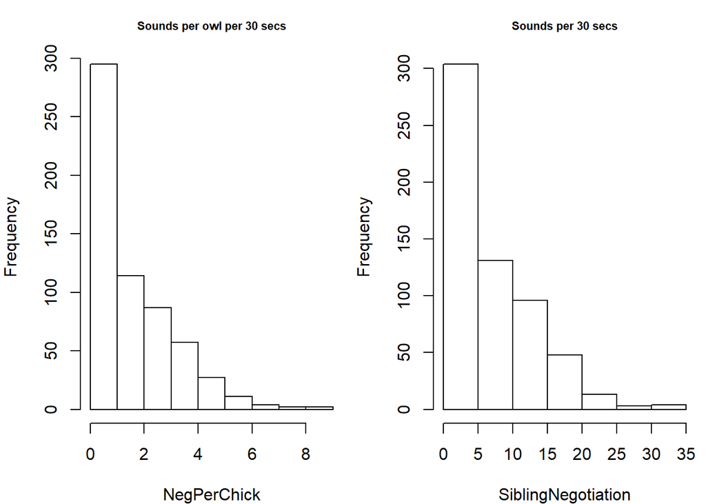

```r
par(mfrow=c(1,2),mar=c(4,4,2.5,0.5))
with(owls,hist(NegPerChick,cex.main=0.7,main="Sounds per owl per 30 secs",))
with(owls,hist(SiblingNegotiation,cex.main=0.7,main="Sounds per 30 secs"))
```

```r
owls$LBroodSize=log(owls$BroodSize)
```

We can also look at brood sizes

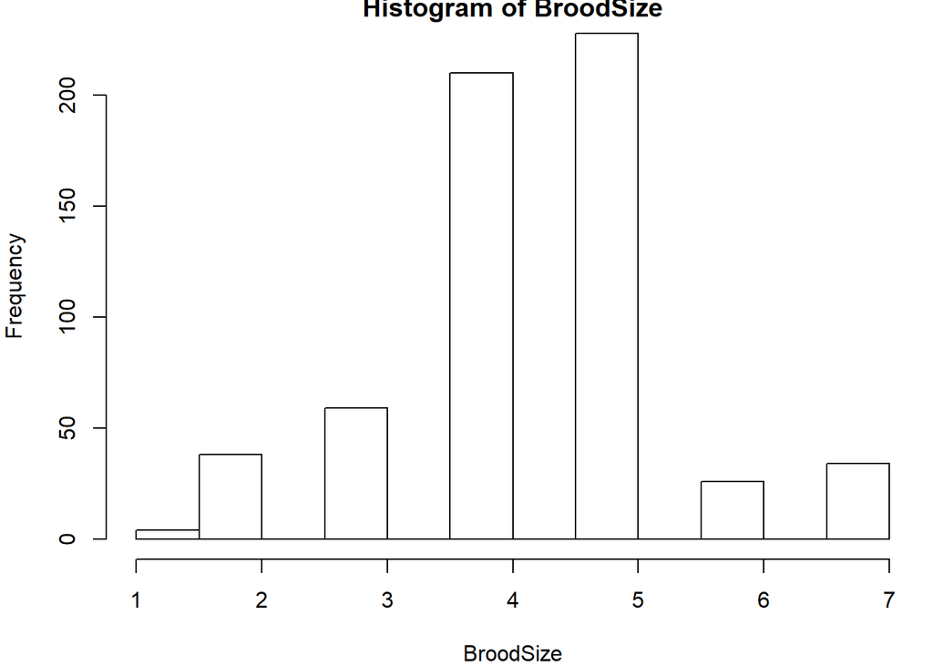

```r
par(mfrow=c(1,1),mar=c(4,4,0.5,0.5))
with(owls,hist(BroodSize))
```

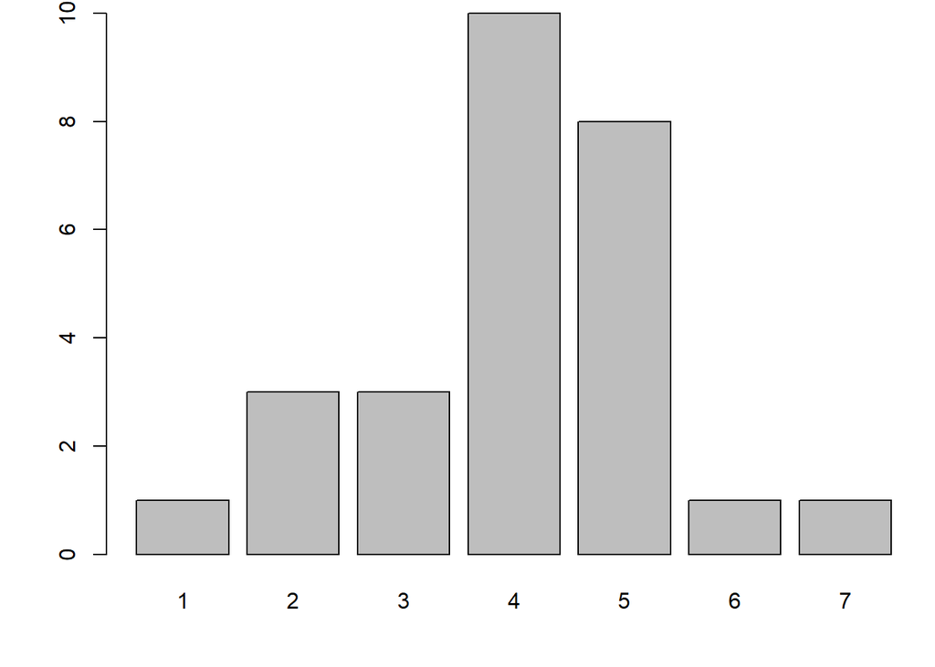

```r
barplot(table((with(owls,
tapply(X=BroodSize,INDEX=Nest,mean)))))
```

We can see that we have 27 nests, and the number of observations per nest varied between 4 and 52.

We actually have repeated measurements in nests over two nights, one where the animals were starved, the other where the animals were fed. This is described by `FoodTreatment`.

In that respect, we have a relatively balanced number of records per night.

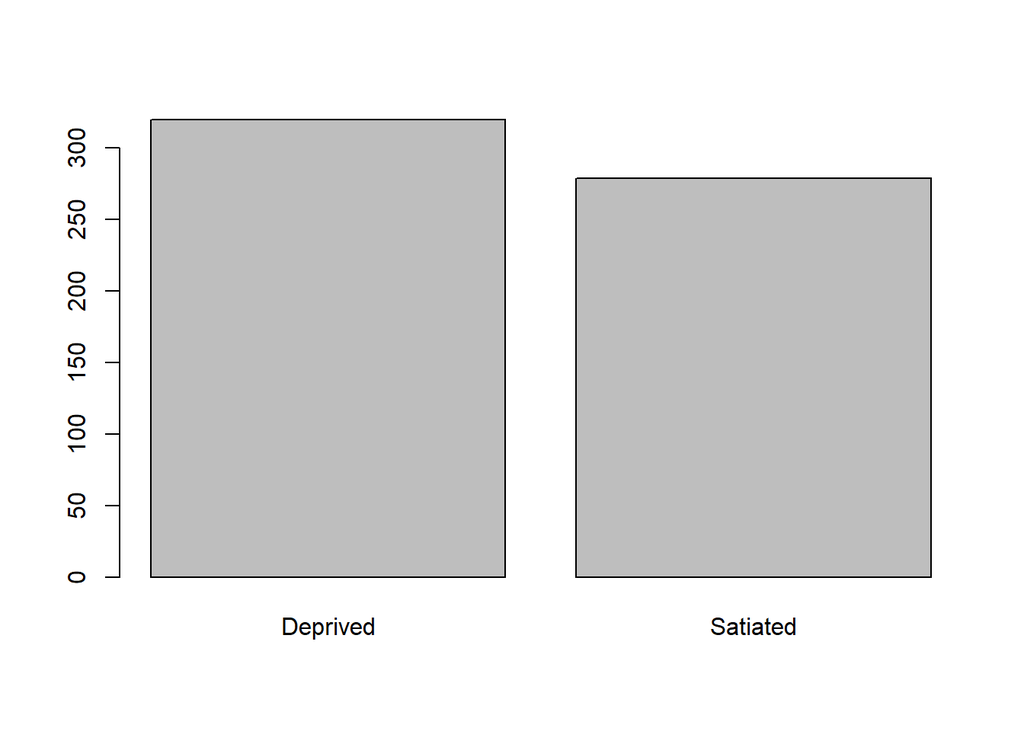

```r
with(owls,barplot(table(FoodTreatment)))
```

Since the chicks were tested in two different nights, one when they were food deprived and one when they were not food deprived, there are actually twice as many groups of observations than the number of nests, and building a covariate that represents this will be useful for later

```r
#doing Zuurs suggestion in pag. 317 with horrible code
#but with 1 line of code :)
owls$NestNight=as.factor(paste0(owls$Nest,".",substr(owls$FoodTreatment,1,3)))
```

Finally, it was also recorded the sex of the parent that arrived to the next

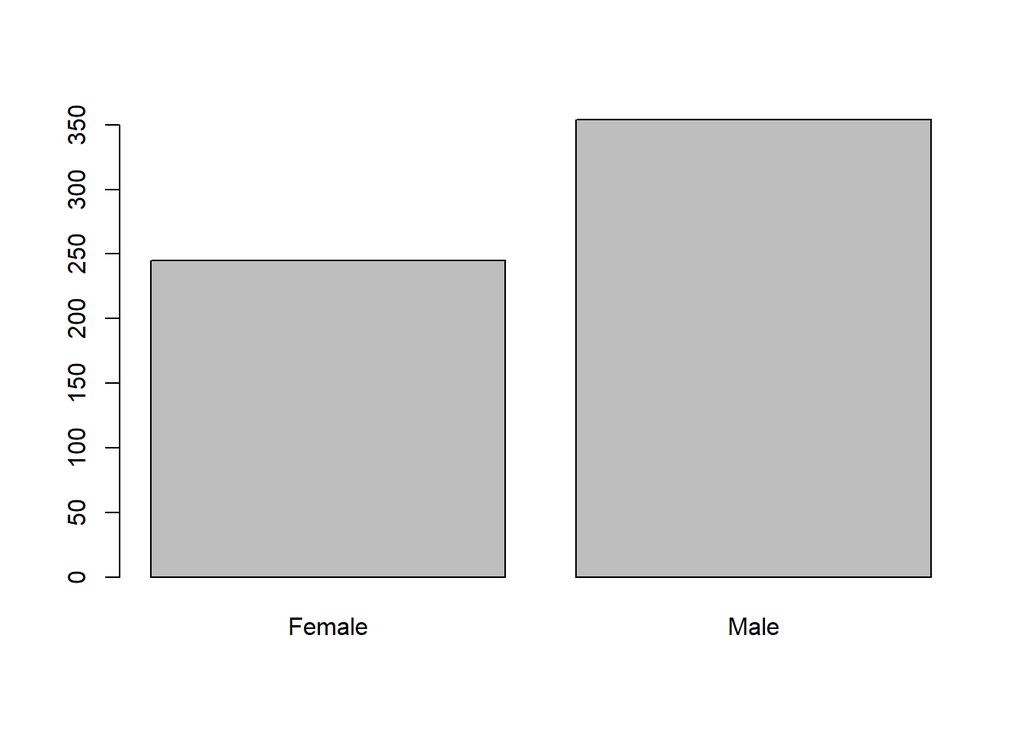

```r
with(owls,barplot(table(SexParent)))
```

and there again there’s no large differences, although it was more often the male than the female.

A final note to the variable `ArrivalTime` which describes the time of the start of each 30 second period

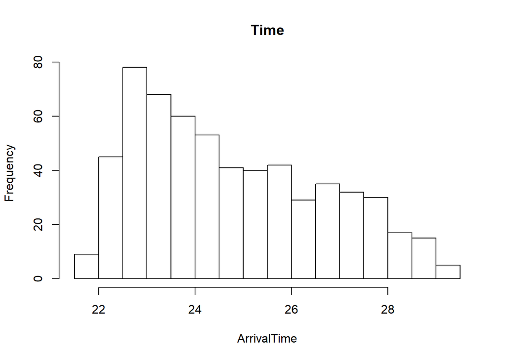

```r
with(owls,hist(ArrivalTime,main="Time"))
```

Note it is not that clear what are the units, but we assume here that the larger the number the later in the night.

# Modeling the data

## GEE’s

This is a GEE that retains the factors considered relevant from previous analysis.

```r
fmodelo <- formula(SiblingNegotiation∼offset(LBroodSize)+FoodTreatment+ArrivalTime)
mod.by.nest <- geeglm(formula=fmodelo,data=owls,family = poisson,id = Nest, corstr = "ar1")
summary(mod.by.nest)
```

```
##
## Call:
## geeglm(formula = fmodelo, family = poisson, data = owls, id = Nest,
##     corstr = "ar1")
##
##  Coefficients:
##                       Estimate  Std.err  Wald Pr(>|W|)
## (Intercept)            3.70322  0.66935 30.61 3.16e-08 ***
## FoodTreatmentSatiated -0.56417  0.12254 21.20 4.15e-06 ***
## ArrivalTime           -0.12418  0.02691 21.30 3.93e-06 ***
## ---
## Signif. codes:  0 '***' 0.001 '**' 0.01 '*' 0.05 '.' 0.1 ' ' 1
##
## Estimated Scale Parameters:
##             Estimate Std.err
## (Intercept)    6.242   0.387
##
## Correlation: Structure = ar1  Link = identity
##
## Estimated Correlation Parameters:
##       Estimate Std.err
## alpha   0.3854  0.0582
## Number of clusters:   27   Maximum cluster size: 52
```

Note the numbers of groups and maximum number of observations per group add up to the data in `Nest`

```r
max(table(owls$Nest))
```

```
## [1] 52
```

```r
length(unique(owls$Nest))
```

```
## [1] 27
```

However, when we consider the relevant variable for the grouping, which is the one we built ourselves, `NestNight`, we don’t get that

```r
mod.by.nestnight <- geeglm(formula=fmodelo,data=owls,family = poisson,id=NestNight,corstr="ar1")
summary(mod.by.nestnight)
```

```
##
## Call:
## geeglm(formula = fmodelo, family = poisson, data = owls, id = NestNight,
##     corstr = "ar1")
##
##  Coefficients:
##                       Estimate Std.err Wald Pr(>|W|)
## (Intercept)              3.593   0.668 28.9  7.6e-08 ***
## FoodTreatmentSatiated   -0.578   0.115 25.4  4.6e-07 ***
## ArrivalTime             -0.122   0.027 20.3  6.6e-06 ***
## ---
## Signif. codes:  0 '***' 0.001 '**' 0.01 '*' 0.05 '.' 0.1 ' ' 1
##
## Estimated Scale Parameters:
##             Estimate Std.err
## (Intercept)     6.64   0.524
##
## Correlation: Structure = ar1  Link = identity
##
## Estimated Correlation Parameters:
##       Estimate Std.err
## alpha    0.517  0.0676
## Number of clusters:   277   Maximum cluster size: 18
```

The numbers of groups and maximum observations per group do not add up…, as we can see below… why? What am I missing?

```r
max(table(owls$NestNight))
```

```
## [1] 28
```

```r
length(unique(owls$NestNight))
```

```
## [1] 54
```

Given this, we were expecting that the output referred that Number of clusters: 54 Maximum cluster size: 28. Where do the 277 and 18 come from?